# How to use GCtoMAT_v4

Brian Whyte

November 22, 2018

## The purpose of this code

“GCtoMAT” (meaning “GC to matrix”) gathers multiple chromatograph outputs from a gas chromatograph (GC) and automatically organizes their useful data into one matrix or “master table” in which areas from peaks at similar retention times (RT’s) can be compared to each other. Gathering peak data from hundreds of files is tedious and software that does it for you is hard to come by. This code aims to makes such analysis possible to anyone doing research involving GC data. Following this intent, this code is written to use .csv files from “.D” folders as its only input, since .D folders appear to be the universal output that Agilent GC/MS machines store data in each time they run a sample. No extra software for viewing/modifying/or arranging GC files is required to use this code.

This document shows you *how to use* this code, not *how to understand* what each command line is doing. Therefore, I will only discuss how to set up your folders and files, run the script, and interpret its outputs. Once everything is prepared as expected, running the script all at once should give you the master tables you desire.

## Outline:

1. Set up working directories
2. Running the script + fixing potential errors
3. Reading + modifying the master tables

### PART I: Set up working directories

To access all the data in the .D folders and begin merging them together, the RESULTS.CSV files within each .D folder must be identified and extracted into a single working directory. To do this, all the folders are placed in one directory (e.g. “…/C20_Tests/Files/”), and all their .CSV files are copied and moved into the directory preceeding it (e.g. “…/C20_Tests/”). These are referred to as the secondary and primary directories, respectively.

```r
## Set PRIMARY and SECONDARY directories
PRIMARY_DIR <- "C:/Users/Brian/Desktop/R_folder/GCtoMAT/C20_Tests"
SECONDARY_DIR <- "C:/Users/Brian/Desktop/R_folder/GCtoMAT/C20_Tests/Files"
```

**You will need to change these to your own working directories**. Gathering your .D folders into your secondary directory, and defining your primary and secondary directories in the script is the only thing you have to do before running the code.

If this is not making sense, maybe the images at the end of this document will help. Before running the first block of code (i.e. *BLOCK 1: Set up + clean up*), your primary directory should look similar to FIG 1. Within that primary directory is the secondary directory (e.g. the “Files” folder), where all the unmodified .D folders fresh from the GC are contained (FIG 2). After running the first block of code, your primary directory should have all the .csv files renamed and copied into it (FIG 3). If your directories look similar, you should be ready to run the rest of the script.

### PART II: Running the script + fixing potential errors

In R studio, you can run the entire script with the “Source” option, next to the “Run” option (which only runs what you have selected). If you are worried about getting errors, you can run each command line one-by-one, such that when errors occur you know exactly where they are occuring. Errors can occur for many unpredictable reasons, but here are some things you should check first if the code is not working for you:

- *Empty .CSV files*
  - Even if no data is collected from a GC run due to an error, a .D folder with a RESULTS.CSV file is still generated. Double check to make sure you aren’t including any empty .CSV files in your collection of .D folders. These empty files will prevent a master table from being formed.
- *Different RESULTS.CSV layout*
  - In the for-loop for gathering RT and Area data from RESULTS.CSV files (below), we assume that:
    - the first 7 rows of the file are useless info to be removed
    - RT and Area data is found in column 3 and 9 specifically.
    - A “[PBM Peak average]” section is generated, and needs to be removed.
  - Make sure these assumptions are true for your RESULTS.CSV files. If your GC generates these .CSVs slightly differently, you can modify the first 3 command lines in this for-loop to fit your unique .CSV layouts.

```r
## Gather .csv data into list, where each object is RT or Area data from .csv's
for (i in 1:length(names)) {
  df <- assign(names[i], read.csv(names[i],skip=7,dec=".",sep=",")) # read first .csv, skipping useless first rows
  df <- df[-(which(df == "[PBM Peak average]", arr.ind = TRUE)[1]:nrow(df)),] # remove PBM section
  df <- df[c(3,9)] # remove all but RT and Area columns
  colnames(df) <- c("RT","Area")
  n <- names[i]
  l[[paste(c(n,"_RT"),sep="",collapse="")]] <- df$RT
  l[[paste(c(n,"_Area"),sep="",collapse="")]] <- df$Area
}
```

### PART III: Reading + modifying the master tables

If you succeed in running this code with your data, BASE (FIG 4) and ROUNDED (FIG 5) matrices are generated. The base matrix creates a column for every unique RT value down to the millisecond. In other words, a peak recorded at 6.323 minutes is considered different from a peak recorded at 6.322 minutes, and gets its own column where its corresponding area data is stored. Of course, these peaks can be interpreted as the same compounds separated by just a millisecond, but this is a subjective call that everyone has to make when analyzing GC data.

We offer the ROUNDED matrices as a way to systematically work around this, assuming every RT can be rounded to the nearest second, or even rounded to the nearest minute. For example, if RTs are rounded to the nearest second, they would be rounded to the 2nd digit after the decimal:

```r
##R2_MATRIX: masterRT rounded to second digit, with area's aggregated
r2_m <- m
r2_m[,1] = round(r2_m[,1],2) # round the masterRT to the second digit
r2_m <- as.data.frame(r2_m) # make data frame before using aggregate
r2_m <- aggregate(. ~ masterRT, data=r2_m, FUN=sum) # sum's up area values in a column based on shared masterRT
r2_m <- t(r2_m)
write.csv(r2_m,file="0-R2_matrix.csv",row.names=TRUE)
```

This would mean a peak at 6.323 minutes would be put in the same column as a peak at 6.322 minutes. If these two peaks are found *in the same .csv file*, their area’s are summed together. If they are come from different .csv files, they are placed in the same column, but in separate rows, each row corresponding to the .csv file they came from.

**The rounding step is entirely subjective, and should be modified for each user**. In our case, millisecond differences between RTs can be ignored, but RTs separated by a minute or more could be different compounds, likely needing further investigation. While these master tables require further modifications and manipulations depending on each user’s research questions and planned analyses, having hundreds of files worth of GC data all organized into one table can make comparisons much easier, preparing your code for statistical analyses in one quick step.

### **PICTURES**

#### *FIG 1: Primary directory BEFORE running block 1*

[figure not shown]

#### *FIG 2: Secondary directory, holding the .D folders*

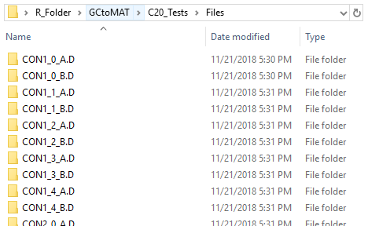

#### *FIG 3: Primary directory AFTER running block 1*

[figure not shown]

#### *FIG 4: Base matrix. Column = RTs. Row = Area data for each .csv*

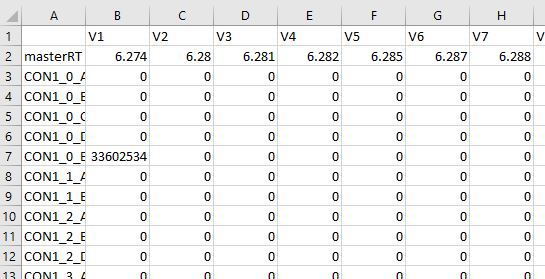

#### *FIG 5: R1 matrix (rounded to first decimal). Column = RTs. Row = Area data for each .csv*

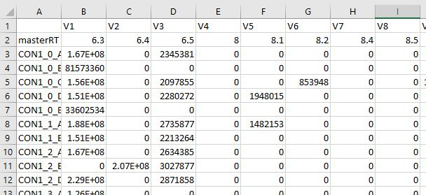